# R Notebook

## 1.

### a)

```r
dd <- read.table("http://www-eio.upc.es/%7Ejan/Data/MVA/cmc.dat", header = T, sep=',')
attach(dd)
head(dd)
```

|  | Age | WifeEduc | HusbEduc | Childs | Rel | Work | Occup | Standard | Media | Method |
| --- | --- | --- | --- | --- | --- | --- | --- | --- | --- | --- |
| 1 | 24 | 2 | 3 | 3 | 1 | 1 | 2 | 3 | 0 | 1 |
| 2 | 45 | 1 | 3 | 10 | 1 | 1 | 3 | 4 | 0 | 1 |
| 3 | 43 | 2 | 3 | 7 | 1 | 1 | 3 | 4 | 0 | 1 |
| 4 | 42 | 3 | 2 | 9 | 1 | 1 | 3 | 3 | 0 | 1 |
| 5 | 36 | 3 | 3 | 8 | 1 | 1 | 3 | 2 | 0 | 1 |
| 6 | 19 | 4 | 4 | 0 | 1 | 1 | 3 | 3 | 0 | 1 |

```r
summary(dd)
```

```
      Age           WifeEduc        HusbEduc        Childs
 Min.   :16.00   Min.   :1.000   Min.   :1.00   Min.   : 0.000
 1st Qu.:26.00   1st Qu.:2.000   1st Qu.:3.00   1st Qu.: 1.000
 Median :32.00   Median :3.000   Median :4.00   Median : 3.000
 Mean   :32.54   Mean   :2.959   Mean   :3.43   Mean   : 3.261
 3rd Qu.:39.00   3rd Qu.:4.000   3rd Qu.:4.00   3rd Qu.: 4.000
 Max.   :49.00   Max.   :4.000   Max.   :4.00   Max.   :16.000
      Rel              Work            Occup          Standard
 Min.   :0.0000   Min.   :0.0000   Min.   :1.000   Min.   :1.000
 1st Qu.:1.0000   1st Qu.:0.0000   1st Qu.:1.000   1st Qu.:3.000
 Median :1.0000   Median :1.0000   Median :2.000   Median :3.000
 Mean   :0.8506   Mean   :0.7495   Mean   :2.138   Mean   :3.134
 3rd Qu.:1.0000   3rd Qu.:1.0000   3rd Qu.:3.000   3rd Qu.:4.000
 Max.   :1.0000   Max.   :1.0000   Max.   :4.000   Max.   :4.000
     Media           Method
 Min.   :0.000   Min.   :1.00
 1st Qu.:0.000   1st Qu.:1.00
 Median :0.000   Median :2.00
 Mean   :0.074   Mean   :1.92
 3rd Qu.:0.000   3rd Qu.:3.00
 Max.   :1.000   Max.   :3.00
```

```r
Age < 5 || Age > 70
```

```
[1] FALSE
```

```r
WifeEduc!=1 && WifeEduc!=2 && WifeEduc!=3 && WifeEduc!=4
```

```
[1] FALSE
```

```r
HusbEduc!=1 && HusbEduc!=2 && HusbEduc!=3 && HusbEduc!=4
```

```
[1] FALSE
```

```r
sum(Childs>4)
```

```
[1] 368
```

```r
sum(Childs==16)
```

```
[1] 1
```

```r
Rel!=0 && Rel!=1
```

```
[1] FALSE
```

```r
Work!=0 && Work!=1
```

```
[1] FALSE
```

```r
Occup!=1 && Occup!=2 && Occup!=3 && Occup!=4
```

```
[1] FALSE
```

```r
Standard!=1 && Standard!=2 && Standard!=3 && Standard!=4
```

```
[1] FALSE
```

```r
Media!=0 && Media!=1
```

```
[1] FALSE
```

```r
Method!=1 && Method!=2 && Method!=3
```

```
[1] FALSE
```

```r
dd[is.na(dd)]
```

```
integer(0)
```

A priori no parece haber datos incompletos, pero llama la atención que haya una mujer que haya tenido 16 hijos y 368 con más de 4.

### b)

```r
dd$Method[Method==1] <- "3none"
dd$Method[Method==2] <- "1long-term"
dd$Method[Method==3] <- "2short-term"
dd$Method <- as.factor(dd$Method)
dd$WifeEduc[WifeEduc==1] <- "4low"
dd$WifeEduc[WifeEduc==2] <- "3medium-low"
dd$WifeEduc[WifeEduc==3] <- "2medium-high"
dd$WifeEduc[WifeEduc==4] <- "1high"
dd$WifeEduc <- as.factor(dd$WifeEduc)
detach(dd)
attach(dd)
```

### c)

```r
(cont <- table(Method, WifeEduc))
```

```
             WifeEduc
Method        1high 2medium-high 3medium-low 4low
  1long-term    207           80          37    9
  2short-term   195          155         121   40
  3none         175          175         176  103
```

### d)

```r
chi.test <- chisq.test(Method, WifeEduc)
chi.test$statistic
```

```
X-squared
 140.4589
```

```r
chi.test$p.value
```

```
[1] 8.01877e-28
```

Con un p-valor tan bajo rechazamos la hipótesis nula, es decir, existe algún tipo de correlación entre ambas variables.

### e)

```r
# Columna
(c <- apply(cont, 2, sum))
```

```
       1high 2medium-high  3medium-low         4low
         577          410          334          152
```

```r
# Fila
(r <- apply(cont, 1, sum))
```

```
 1long-term 2short-term       3none
        333         511         629
```

El método más utilizado es ningún método.

### f)

```r
Dr <- diag(r)
Dc <- diag(c)
(R <- solve(Dr)%*%cont)
```

```
      WifeEduc
           1high 2medium-high 3medium-low       4low
  [1,] 0.6216216    0.2402402   0.1111111 0.02702703
  [2,] 0.3816047    0.3033268   0.2367906 0.07827789
  [3,] 0.2782194    0.2782194   0.2798092 0.16375199
```

```r
(C <- t(solve(Dc)%*%t(cont)))
```

```
Method             [,1]      [,2]      [,3]       [,4]
  1long-term  0.3587522 0.1951220 0.1107784 0.05921053
  2short-term 0.3379549 0.3780488 0.3622754 0.26315789
  3none       0.3032929 0.4268293 0.5269461 0.67763158
```

### h)

```r
library(ca)
resultats <- ca(cont)
summary(resultats)
```

```
Principal inertias (eigenvalues):

 dim    value      %   cum%   scree plot
 1      0.090755  95.2  95.2  ************************
 2      0.004600   4.8 100.0  *
        -------- -----
 Total: 0.095356 100.0


Rows:
    name   mass  qlt  inr    k=1 cor ctr    k=2 cor ctr
1 | 1lng |  226 1000  605 |  502 988 629 |   54  12 145 |
2 | 2shr |  347 1000   33 |   18  36   1 |  -93 964 652 |
3 | 3non |  427 1000  362 | -280 973 370 |   47  27 203 |

Columns:
    name   mass  qlt  inr    k=1 cor ctr    k=2 cor ctr
1 | 1hgh |  392 1000  468 |  336 990 487 |   33  10  95 |
2 | 2mdm |  278 1000   21 |  -50 350   8 |  -68 650 277 |
3 | 3mdm |  227 1000  197 | -284 976 202 |  -45  24  98 |
4 | 4low |  103 1000  314 | -517 919 303 |  154  81 531 |
```

En la solución aparecen solo dos dimensiones. La tabla se puede representar de manera exacta con $min(I-1, J-1)$ dimensiones, que en este caso son dos porque hay tres filas y cuatro columnas.

### i)

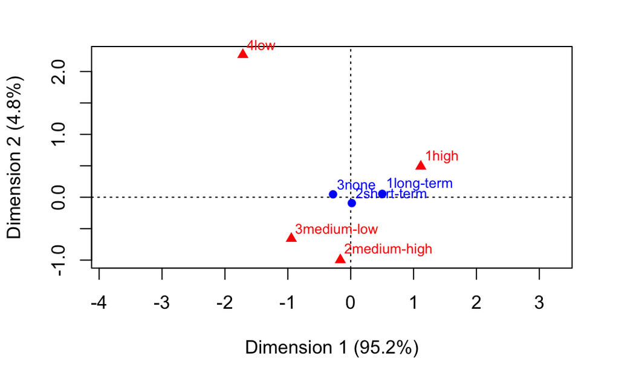

```r
plot(resultats, map="rowprincipal")
```

Observamos que el perfil de mujer con más estudios es el que más proyecta sobre métodos anticonceptivos a largo plazo. También vemos una diferencia desproporcionada entre el nivel mínimo de estudios y el resto, el cual proyecta de forma excesiva sobre no usar método alguno. Ambos resultados parecen ir a favor de la intuición.

### k)

```r
dd$Age <- cut(dd$Age, breaks=4)
detach(dd)
attach(dd)
table(Age)
```

```
Age
  (16,24.2] (24.2,32.5] (32.5,40.8]   (40.8,49]
        276         504         387         306
```

### l)

```r
library(tidyr)
dd <- unite(dd, AgeRel, c(Age, Rel), remove=F)
detach(dd)
attach(dd)
table(AgeRel)
```

```
AgeRel
  (16,24.2]_0   (16,24.2]_1 (24.2,32.5]_0 (24.2,32.5]_1 (32.5,40.8]_0
           14           262            62           442            89
(32.5,40.8]_1   (40.8,49]_0   (40.8,49]_1
          298            55           251
```

### m)

```r
(cont2 <- table(AgeRel, Method))
```

```
               Method
AgeRel          1long-term 2short-term 3none
  (16,24.2]_0            2           7     5
  (16,24.2]_1           35         106   121
  (24.2,32.5]_0         18          22    22
  (24.2,32.5]_1         77         195   170
  (32.5,40.8]_0         32          30    27
  (32.5,40.8]_1         85         104   109
  (40.8,49]_0           24          10    21
  (40.8,49]_1           60          37   154
```

### n)

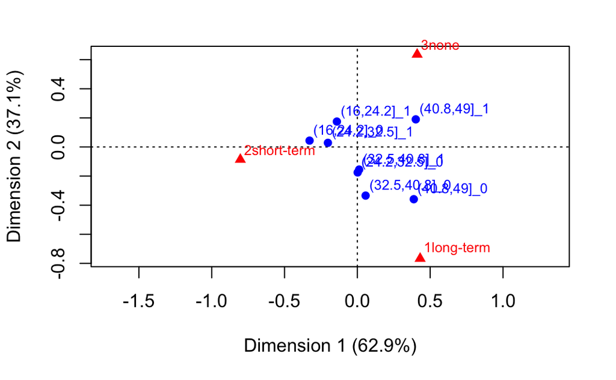

```r
res <- ca(cont2)
plot(res, map="rowgreen")
```

Las mujeres que usan más anticonceptivos a largo plazo son mujeres de mayor edad y de religión no islámica Las que lo usan a corto plazo, son mujeres jovenes no musulmanas y también aunque algo menos las mujeres también jóvenes y de mediana edad musulmanas. Y sorprendentemente el perfil que queda mejor representado por no usar anticonceptivos es el de mujer mayor musulmana.

### o)

```r
out <- mjca(dd[,c("WifeEduc", "Method", "AgeRel")], lambda="indicator")
summary(out)
```

```
Principal inertias (eigenvalues):

 dim    value      %   cum%   scree plot
 1      0.490556  12.3  12.3  ***
 2      0.456773  11.4  23.7  ***
 3      0.357164   8.9  32.6  **
 4      0.345038   8.6  41.2  **
 5      0.334913   8.4  49.6  **
 6      0.333333   8.3  57.9  **
 7      0.333333   8.3  66.3  **
 8      0.321610   8.0  74.3  **
 9      0.299496   7.5  81.8  **
 10     0.279349   7.0  88.8  **
 11     0.232542   5.8  94.6  *
 12     0.215894   5.4 100.0  *
```

[output cut: 37 more lines]

```r
out$inertia.t
```

```
[1] 4
```

El análisis se lleva acabo con doce dimensiones, la inercia total es 4, y la bondad del ajuste en dos dimensiones es del 23.7%.

### p)

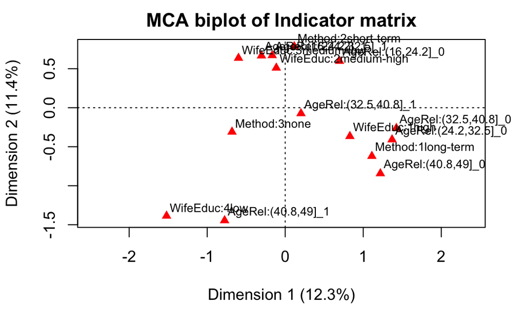

```r
plot(out, main="MCA biplot of Indicator matrix")
```

Aquí podemos ver que mujeres con poca educación suelen ser mayores y musulmanas, y que a su vez son las que más tienden a no usar anticonceptivos. Por otro lado, también se ven dos cúmulos de puntos que vienen a decir que el nivel de educación alto, el usar métodos a largo plazo, y el no ser musulmana ni jóven está correlacionado. Mientras que ser joven o musulmana pero no mayor, tener educación media y usar métodos a corto plazo también está correlacionado.

### q)

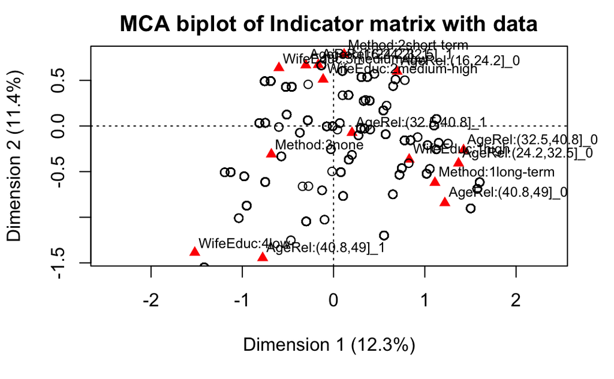

```r
plot(out, main="MCA biplot of Indicator matrix with data")
points(out$rowpcoord[,1], out$rowpcoord[,2])
```

Están representadas pero parcialmente ya que hay muchos puntos superpuestos, en el gráfico no se observan 1473 puntos ni mucho menos sin embargo sí que hay 1473 puntos como se observa aquí

```r
dim(out$rowpcoord)
```

```
[1] 1473   12
```

### r)

```r
out2 <- mjca(dd[,c("WifeEduc", "Method", "AgeRel")], lambda="Burt")
summary(out2)
```

```
Principal inertias (eigenvalues):

 dim    value      %   cum%   scree plot
 1      0.240645  17.2  17.2  ****
 2      0.208641  14.9  32.0  ****
 3      0.127566   9.1  41.1  **
 4      0.119051   8.5  49.6  **
 5      0.112167   8.0  57.6  **
 6      0.111111   7.9  65.6  **
 7      0.111111   7.9  73.5  **
 8      0.103433   7.4  80.9  **
 9      0.089698   6.4  87.3  **
 10     0.078036   5.6  92.8  *
 11     0.054076   3.9  96.7  *
 12     0.046610   3.3 100.0  *
```

[output cut: 37 more lines]

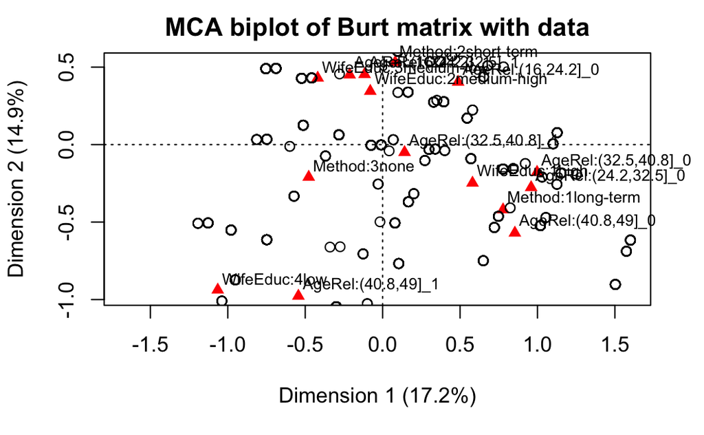

```r
plot(out2, main="MCA biplot of Burt matrix with data")
points(out2$rowpcoord[,1], out$rowpcoord[,2])
```

```r
detach(dd)
```

# 2 Características esqueléticas de hombres y mujeres

### a)

```r
esq <- read.table("http://www-eio.upc.es/%7Ejan/Data/MVA/body.dat")
esq <- esq[,c(1:9,25)]
colnames(esq) <- c("Biacromial.diam", "Biiliac.diam", "Bitrochanteric.diam", "Chest.depth", "Chest.diam", "Elbow.diam", "Wrist.diam", "Knee.diam", "Ankle.diam", "Gender")
esq$Gender <- as.factor(esq$Gender)
head(esq)
```

|  | Biacromial.diam | Biiliac.diam | Bitrochanteric.diam | Chest.depth | Chest.diam | Elbow.diam | Wrist.diam | Knee.diam | Ankle.diam | Gender |
| --- | --- | --- | --- | --- | --- | --- | --- | --- | --- | --- |
| 1 | 42.9 | 26.0 | 31.5 | 17.7 | 28.0 | 13.1 | 10.4 | 18.8 | 14.1 | 1 |
| 2 | 43.7 | 28.5 | 33.5 | 16.9 | 30.8 | 14.0 | 11.8 | 20.6 | 15.1 | 1 |
| 3 | 40.1 | 28.2 | 33.3 | 20.9 | 31.7 | 13.9 | 10.9 | 19.7 | 14.1 | 1 |
| 4 | 44.3 | 29.9 | 34.0 | 18.4 | 28.2 | 13.9 | 11.2 | 20.9 | 15.0 | 1 |
| 5 | 42.5 | 29.9 | 34.0 | 21.5 | 29.4 | 15.2 | 11.6 | 20.7 | 14.9 | 1 |
| 6 | 43.3 | 27.0 | 31.5 | 19.6 | 31.3 | 14.0 | 11.5 | 18.8 | 13.9 | 1 |

```r
attach(esq)
```

### b)

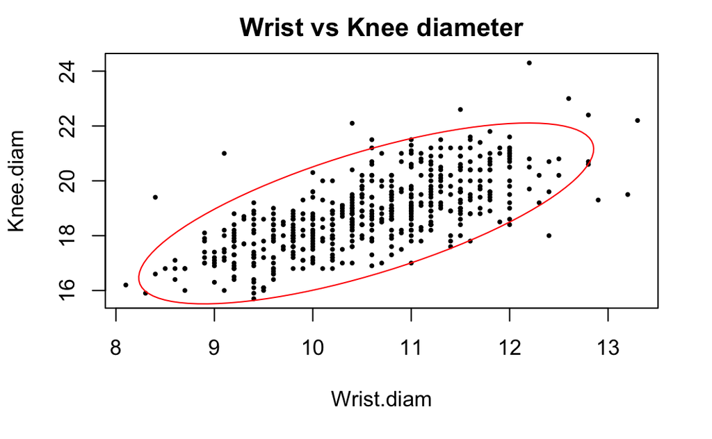

```r
plot(Wrist.diam, Knee.diam, main="Wrist vs Knee diameter", pch=16, cex=0.5)
mean.WK <- c(mean(Wrist.diam), mean(Knee.diam))
WK <- data.frame(Wrist.diam, Knee.diam)
cov.WK <- cov(WK)
library(ellipse)
contour.WK <- ellipse(cov.WK, centre=mean.WK)
lines(contour.WK[,1], contour.WK[,2], col = "red")
```

### c) Caen 19 fuera. Esperaríamos que cayeran fuera alrededor del 5% de los puntos, es decir 25 puntos.

### d) Si la función de densidad de un punto da un valor menor que el valor que dan los puntos del contorno, entonces está fuera de la elipse. Aunque también se puede calcular geométricamente sabiendo los ejes de la elipse y su centro.

```r
# Método 1 (Geométrico)
plot(Wrist.diam, Knee.diam, main="Wrist vs Knee diameter", pch=16, cex=0.5)
lines(contour.WK[,1], contour.WK[,2], col = "red")
```

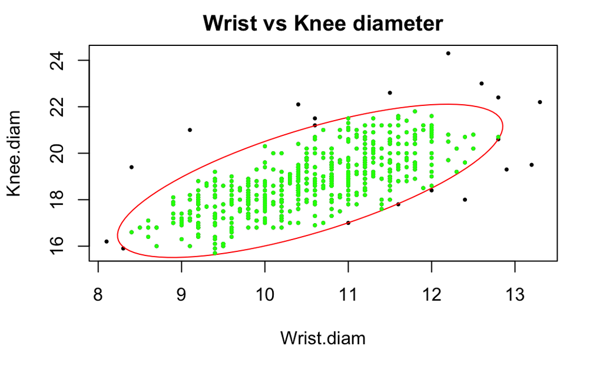

```r
library(SIBER)
Z <- pointsToEllipsoid(WK, cov.WK, mean.WK)
inside <- ellipseInOut(Z)
points(WK[inside,], pch=16, col="green", cex=0.5)
```

```r
# Método 2 (Estadístico)
library(mvtnorm)
limit <- dmvnorm(contour.WK[1,], mean=mean.WK, sigma=cov.WK)
outside <- dmvnorm(WK, mean=mean.WK, sigma=cov.WK) < limit
plot(Wrist.diam, Knee.diam, main="Wrist vs Knee diameter", pch=16, cex=0.5)
lines(contour.WK[,1], contour.WK[,2], col = "red")
```

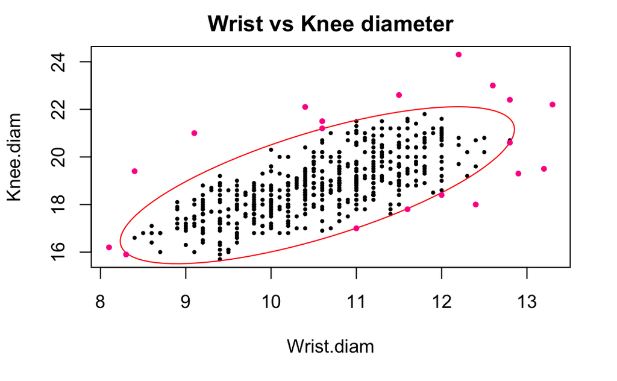

```r
points(WK[outside,], pch=16, col="deeppink", cex=0.7)
```

### e)

```r
detach(esq)
library(dplyr)
esq.f <- filter(esq, Gender==0)
esq.f <- esq.f[,-10]
```

### f) Se espera que se agrupen los puntos en elipses. A grandes rasgos todas las parejas parecen tener la forma deseada. Eso si no consideramos la variable gender que es un factor.

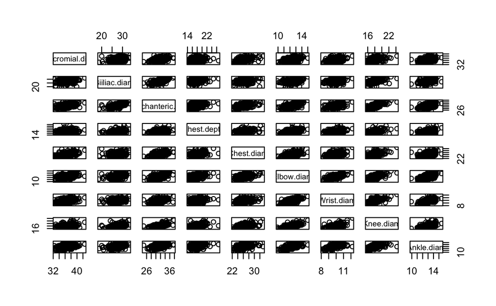

```r
pairs(esq.f)
```

### g)

```r
esq.f.centre <- as.matrix(scale(esq.f, scale=F))
esq.f.cov <- as.matrix(cov(esq.f))
esq.f.cov.inv <- solve(esq.f.cov)
esq.f.dist.sq <- diag((esq.f.centre) %*% esq.f.cov.inv %*% t(esq.f.centre))
(esq.f.dist.sq.ord <- sort(esq.f.dist.sq))
```

```
  [1]  1.614854  1.876730  2.135547  2.293399  2.361022  2.461525
  [7]  2.519774  2.546432  2.661758  2.782444  3.011668  3.096715
 [13]  3.107248  3.116671  3.121416  3.244018  3.283014  3.290570
 [19]  3.309792  3.445509  3.485289  3.490559  3.492904  3.500346
 [25]  3.553546  3.589107  3.840341  3.879719  3.971242  3.985971
 [31]  4.005135  4.017084  4.051308  4.076136  4.096903  4.112500
 [37]  4.129188  4.137548  4.140787  4.175190  4.197765  4.207455
 [43]  4.234116  4.274493  4.330855  4.333695  4.346814  4.398121
 [49]  4.439471  4.455623  4.456969  4.467459  4.471037  4.486168
 [55]  4.493606  4.494330  4.513944  4.523815  4.592725  4.642134
 [61]  4.650526  4.666414  4.670324  4.744588  4.916874  4.928640
 [67]  5.010485  5.094324  5.122366  5.130664  5.136954  5.237419
 [73]  5.260757  5.261181  5.301205  5.331515  5.369237  5.383553
 [79]  5.389557  5.419807  5.481445  5.506699  5.507348  5.522246
 [85]  5.684349  5.719844  5.725653  5.803130  5.827665  5.835961
```

[output cut: 29 more lines]

### h) Tantos grados de libertad como el número de variables.

```r
n <- length(esq.f.dist.sq.ord)
p <- dim(esq)[2]-1
rang <- ((1:n)-0.5)/n
(quantils <- qchisq(rang, df=p))
```

```
  [1]  1.356680  1.801585  2.065751  2.265573  2.430587  2.573321
  [7]  2.700389  2.815752  2.921986  3.020876  3.113711  3.201456
 [13]  3.284855  3.364494  3.440846  3.514296  3.585162  3.653714
 [19]  3.720178  3.784749  3.847596  3.908865  3.968684  4.027167
 [25]  4.084413  4.140514  4.195547  4.249587  4.302697  4.354938
 [31]  4.406363  4.457020  4.506956  4.556212  4.604825  4.652832
 [37]  4.700264  4.747151  4.793523  4.839405  4.884822  4.929796
 [43]  4.974350  5.018503  5.062275  5.105683  5.148744  5.191474
 [49]  5.233888  5.276002  5.317827  5.359377  5.400665  5.441702
 [55]  5.482499  5.523067  5.563416  5.603556  5.643497  5.683246
 [61]  5.722814  5.762207  5.801434  5.840503  5.879421  5.918195
 [67]  5.956833  5.995340  6.033723  6.071989  6.110143  6.148191
 [73]  6.186139  6.223993  6.261757  6.299438  6.337040  6.374568
 [79]  6.412027  6.449422  6.486757  6.524038  6.561267  6.598451
 [85]  6.635592  6.672695  6.709765  6.746805  6.783819  6.820812
```

[output cut: 29 more lines]

### i) Los datos se ajustan bien a la recta salvo por algunos outliers que están a una distancia excesiva en comparación al resto.

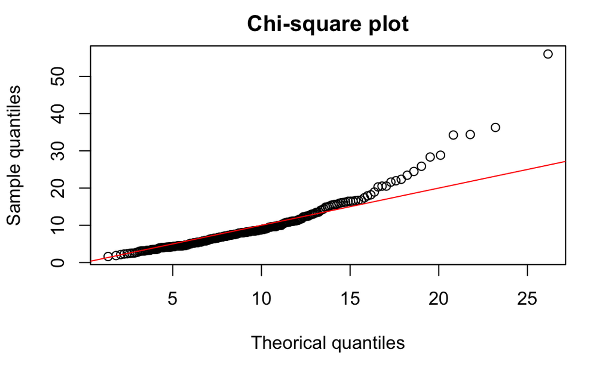

```r
plot(quantils, esq.f.dist.sq.ord, xlab="Theorical quantiles", ylab="Sample quantiles", main="Chi-square plot")
abline(a=0, b=1, col="red")
```

### j) Todas se ajustan bastante bien a una recta, por lo que es factible asumir que las densidades marginales son normales.

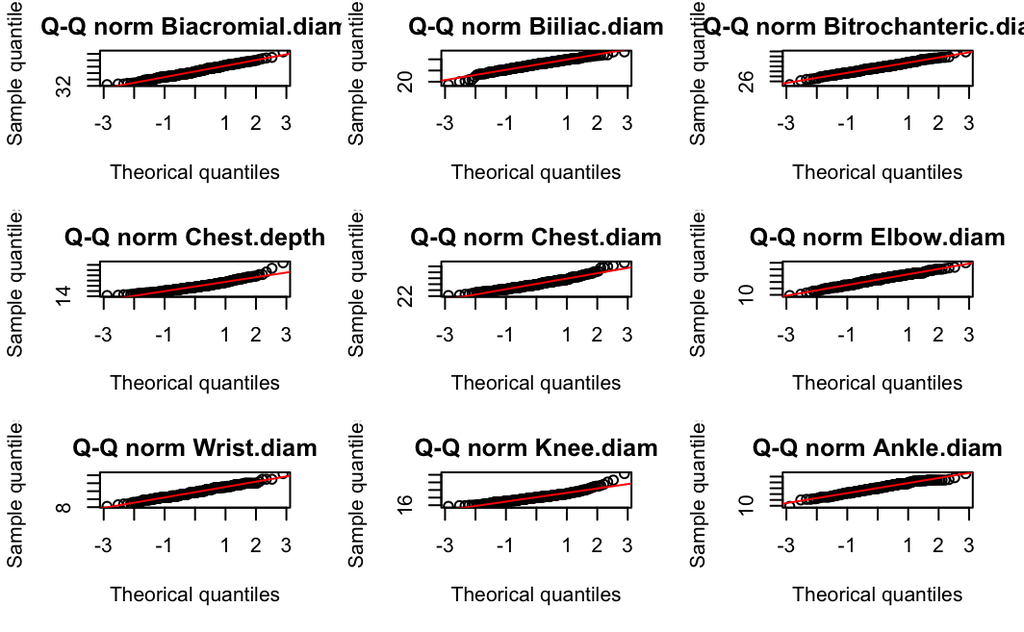

```r
sample.quantils <- apply(esq.f, 2, sort)
th.quantils <- qnorm(rang)
par(mfrow=c(3,3))
for (i in 1:9){
  plot(th.quantils, sample.quantils[,i], xlab="Theorical quantiles", ylab="Sample quantiles", main=paste("Q-Q norm",colnames(esq.f)[i]))
  abline(lm(sample.quantils[,i]~th.quantils), col="red")
}
```

### k) En este caso los puntos parecen seguir la recta de forma casi perfecta, por lo que es bastante probable que sigan una distribución normal multivariada.

```r
esq.m <- filter(esq, Gender==1)
esq.m <- esq.m[,-10]
esq.m.centre <- as.matrix(scale(esq.m, scale=F))
esq.m.cov <- as.matrix(cov(esq.m))
esq.m.cov.inv <- solve(esq.m.cov)
esq.m.dist.sq <- diag((esq.m.centre) %*% esq.m.cov.inv %*% t(esq.m.centre))
esq.m.dist.sq.ord <- sort(esq.m.dist.sq)
n.m <- length(esq.m.dist.sq.ord)
rang <- ((1:n.m)-0.5)/n.m
(quantils.m <- qchisq(rang, df=p))
```

```
  [1]  1.374400  1.826209  2.094777  2.298091  2.466097  2.611505
  [7]  2.741022  2.858664  2.967048  3.067984  3.162779  3.252413
 [13]  3.337641  3.419059  3.497144  3.572289  3.644817  3.715002
 [19]  3.783073  3.849228  3.913639  3.976453  4.037802  4.097801
 [25]  4.156551  4.214143  4.270659  4.326172  4.380749  4.434450
 [31]  4.487328  4.539436  4.590817  4.641515  4.691568  4.741012
 [37]  4.789880  4.838204  4.886011  4.933329  4.980182  5.026595
 [43]  5.072588  5.118183  5.163398  5.208253  5.252765  5.296949
 [49]  5.340822  5.384398  5.427691  5.470713  5.513479  5.556000
 [55]  5.598286  5.640351  5.682203  5.723852  5.765310  5.806584
 [61]  5.847683  5.888617  5.929394  5.970021  6.010505  6.050856
 [67]  6.091079  6.131182  6.171171  6.211053  6.250834  6.290521
 [73]  6.330119  6.369634  6.409072  6.448439  6.487739  6.526979
 [79]  6.566162  6.605295  6.644383  6.683429  6.722440  6.761419
 [85]  6.800371  6.839301  6.878213  6.917112  6.956002  6.994887
```

[output cut: 27 more lines]

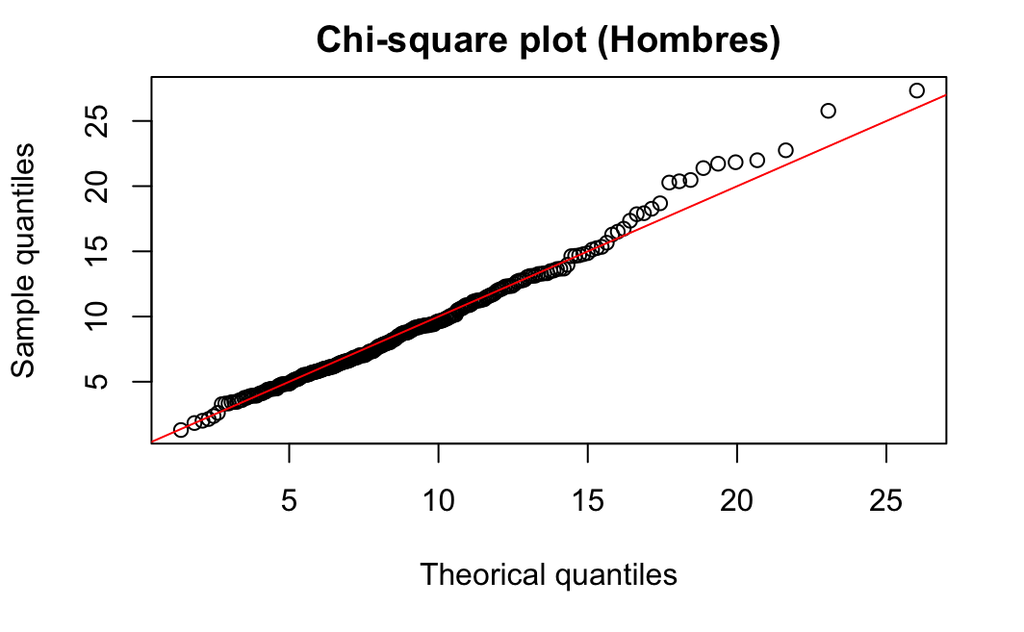

```r
plot(quantils.m, esq.m.dist.sq.ord, xlab="Theorical quantiles", ylab="Sample quantiles", main="Chi-square plot (Hombres)")
abline(a=0, b=1, col="red")
```

### l) El estadístico vale 175.74 y el p-valor es numéricamente 0. Podemos rechazar la hipótesis nula y decir que hay diferencias significativas.

```r
library(ICSNP)
(hot.test <- HotellingsT2(esq.f,esq.m,test="f"))
```

```
    Hotelling's two sample T2-test

data:  esq.f and esq.m
T.2 = 175.74, df1 = 9, df2 = 497, p-value < 2.2e-16
alternative hypothesis: true location difference is not equal to c(0,0,0,0,0,0,0,0,0)
```

```r
hot.test$statistic
```

```
         [,1]
[1,] 175.7402
attr(,"names")
[1] "T.2"
```

```r
hot.test$p.value
```

```
     [,1]
[1,]    0
```

### m) Si asumimos que las matrices de covarianzas pueden no ser iguales sigue saliendo que son diferentes, por tanto, en este caso concreto ambos test dan el mismo resultado.

```r
m1 <- colMeans(esq.f)
m2 <- colMeans(esq.m)
S1 <- cov(esq.f)
S2 <- cov(esq.m)
n1 <- dim(esq.f)[1]
n2 <- dim(esq.m)[1]
(T2 <- (m1-m2)%*%solve(S1/n1+S2/n2)%*%(m1-m2))
```

```
         [,1]
[1,] 1598.917
```

```r
qchisq(0.95,2)
```

```
[1] 5.991465
```

### n) Todas las variables son estadísticamente diferente salvo el diámetro Biiliaco.

```r
for (i in 1:9){
  test.marginal <- t.test(esq.f[,i],esq.m[,i], var.equal=F)
  if (test.marginal$p.value < 0.001) {
    print(paste("Difference in", colnames(esq)[i]))
  } else {
    print(paste("No difference in", colnames(esq)[i]))
  }
}
```

```
[1] "Difference in Biacromial.diam"
[1] "No difference in Biiliac.diam"
[1] "Difference in Bitrochanteric.diam"
[1] "Difference in Chest.depth"
[1] "Difference in Chest.diam"
[1] "Difference in Elbow.diam"
[1] "Difference in Wrist.diam"
[1] "Difference in Knee.diam"
[1] "Difference in Ankle.diam"
```

### o)

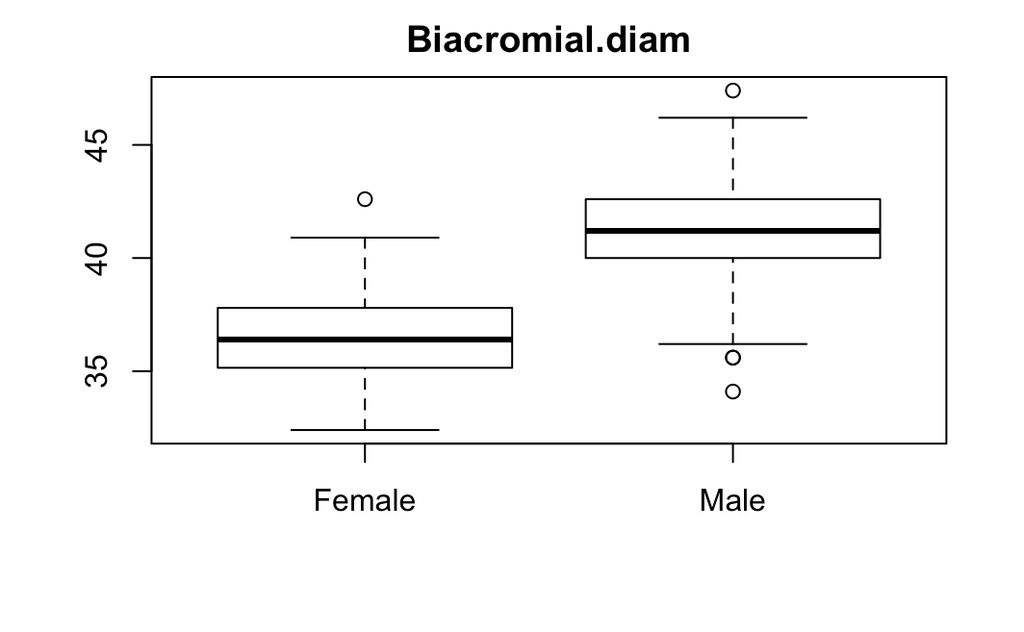

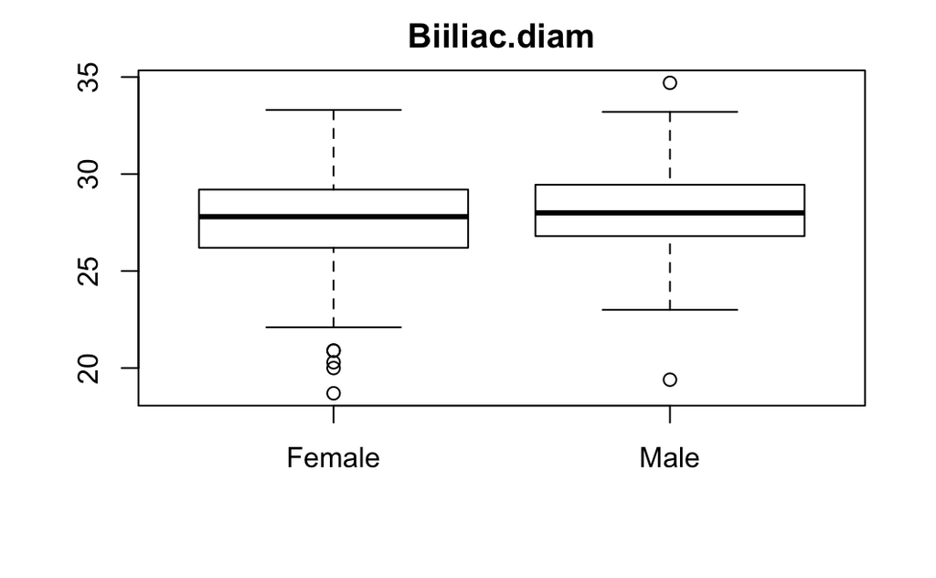

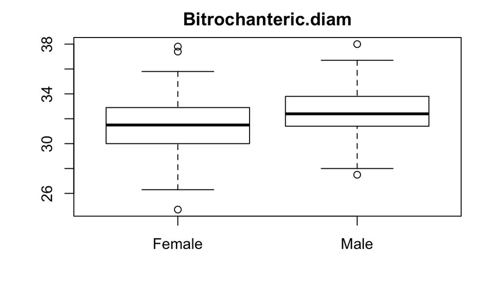

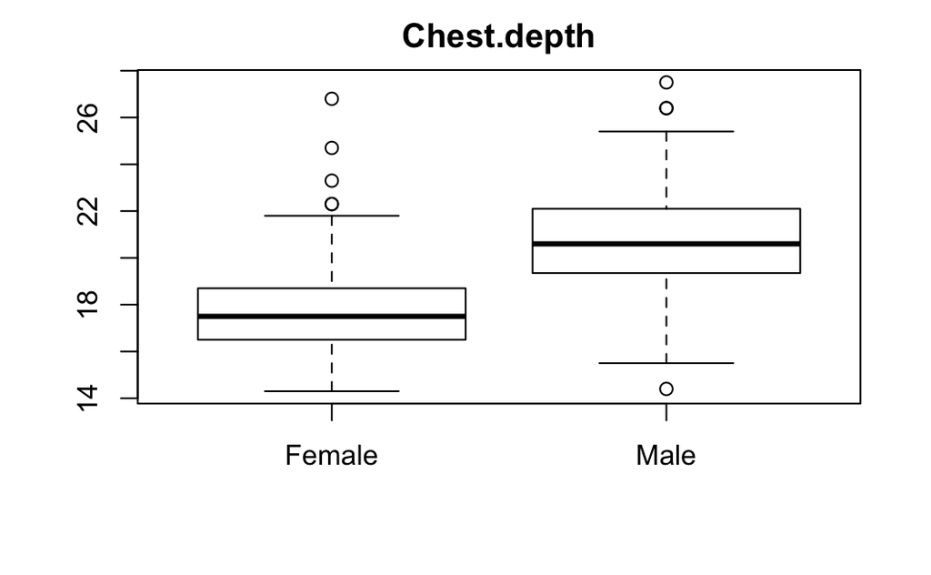

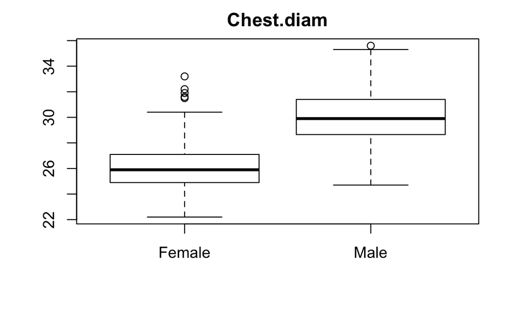

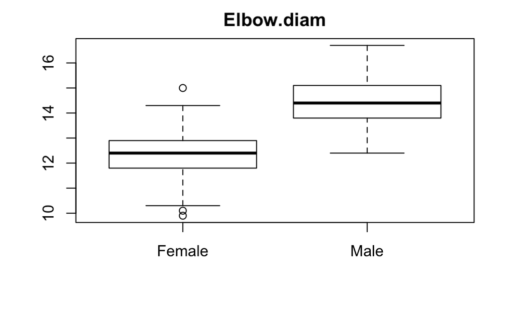

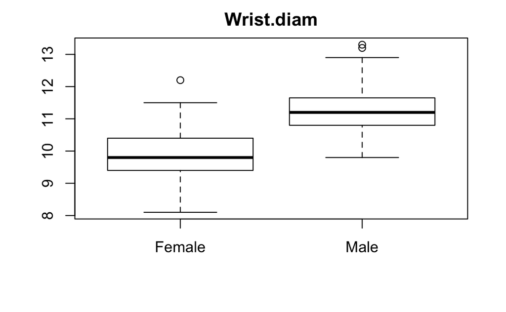

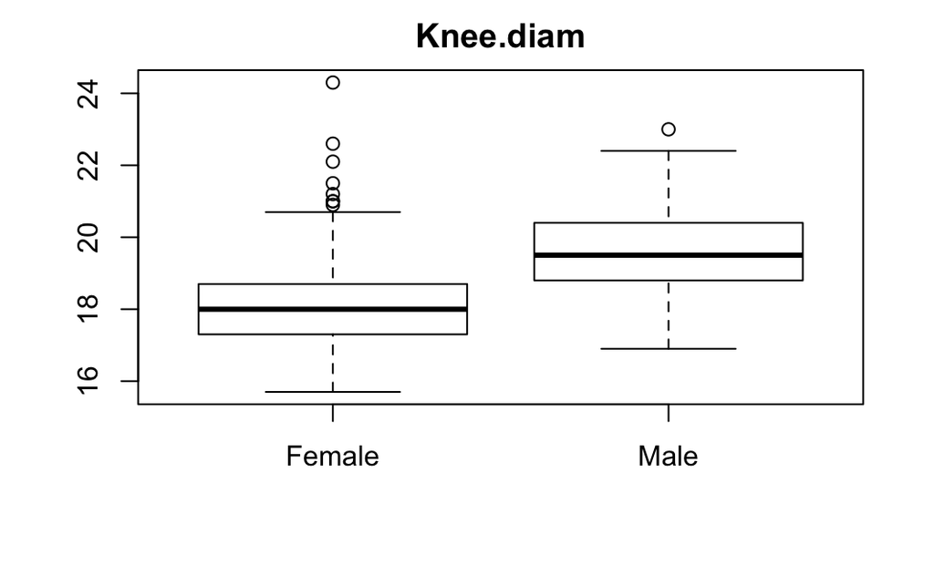

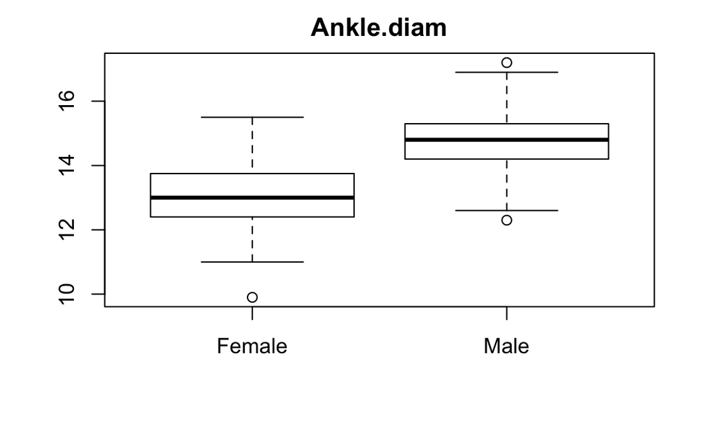

```r
for (i in 1:9){
  boxplot(esq.f[,i], esq.m[,i], names=c("Female","Male"), main=colnames(esq)[i])
}
```